# Lab 04

# Lab 04: Raster data management and analysis

### Read the instructions COMPLETELY before starting the lab

This lab builds directly on the raster analysis concepts we worked through in class, including the Week 12 in-class notebook and the Wildcard Thursday activity. You should have that code available for reference.

### Formatting your submission

This lab must be placed into a public repository on GitHub (www.github.com). Before the due date, submit **on Canvas** a link to the repository. I will then download your repositories and run your code. The code must be contained in either a .R script or a .Rmd markdown document. As I need to run your code, any data you use in the lab must be referenced using **relative path names**. Finally, answers to questions I pose in this document must also be in the repository at the time you submit your link to Canvas. They can be in a separate text file, or if you decide to use an RMarkdown document, you can answer them directly in the doc.

## Data

All data for this lab are in the course repository at:

```
../data/wildcard_thursday/erie_raster_ex/
```

You will find two subdirectories:

- `images/` — seven weekly composite GeoTIFF rasters of cyanobacteria bloom intensity in Lake Erie (summer–fall 2017)
- `bounds/` — several shapefiles representing geographic areas of interest within the Lake Erie region

**Before writing any code, read the metadata file at**

**`../data/wildcard_thursday/erie_raster_ex/erie_README.txt`.**

This is not optional. Understanding your data source, its scaling, and its data key is essential for correct analysis.

## Introduction

Cyanobacteria (blue-green algae) blooms in Lake Erie have become a significant environmental and public health concern. These blooms can produce toxins that contaminate drinking water and harm aquatic ecosystems. The data you will use were produced by NOAA using imagery from the European Space Agency’s Sentinel-3 satellite. Each raster represents the maximum observed bloom intensity during a given week.

The product you will be working with is the **CIcyano** (Cyanobacteria Index, cyano only) product. Values in these rasters are stored as **digital numbers (DN)** and must be transformed to meaningful physical units before interpretation. You saw this in class — recall the reverse-scaling formula from the README and from the Week 12 notebook.

A critical aspect of working with remote sensing data is understanding **sentinel values**: special numeric codes that indicate conditions like cloud cover, land pixels, or missing data. These are NOT real observations and must be handled carefully before any analysis.

We begin by loading the relevant packages:

```r
library(terra)
library(sf)
library(tidyverse)
library(tmap)
library(fs)
```

## Task 1: Data management and preprocessing

### 1.1 Inventory your rasters

Use `fs::dir_ls` with the parameter `regexp = "\\.tif$"` to get the file paths for all raster images in the `images/` directory. Store the result in an object called `raster_files`. Print the result — how many files are there?

```r
# your code here

raster_files <- fs::dir_ls("erie_raster_ex/images/", regexp = "\\.tif$")

raster_files
```

```
## erie_raster_ex/images/ts_2017.0802_0808.L4.LE3.CIcyano.MAXIMUM_7day.tif
## erie_raster_ex/images/ts_2017.0816_0822.L4.LE3.CIcyano.MAXIMUM_7day.tif
## erie_raster_ex/images/ts_2017.0823_0829.L4.LE3.CIcyano.MAXIMUM_7day.tif
## erie_raster_ex/images/ts_2017.0920_0926.L4.LE3.CIcyano.MAXIMUM_7day.tif
## erie_raster_ex/images/ts_2017.0927_1003.L4.LE3.CIcyano.MAXIMUM_7day.tif
## erie_raster_ex/images/ts_2017.1018_1024.L4.LE3.CIcyano.MAXIMUM_7day.tif
## erie_raster_ex/images/ts_2017.1025_1031.L4.LE3.CIcyano.MAXIMUM_7day.tif
```

```r
length(raster_files)
```

```
## [1] 7
```

### 1.2 Inspect a single raster

Load the first raster in your list using `terra::rast()`. Examine the following properties and record what you find:

- Coordinate reference system: `terra::crs()`
- Spatial extent: `terra::ext()`
- Spatial resolution: `terra::res()`
- Number of layers: `terra::nlyr()`
- Range of cell values (use `terra::global()` with `"min"` and `"max"`)

```r
# your code here
# load first raster
r1 <- terra::rast(raster_files[1])

# Coords
terra::crs(r1)
```

```
## [1] "PROJCRS[\"WGS 84 / UTM zone 17N\",\n    BASEGEOGCRS[\"WGS 84\",\n        DATUM[\"World Geodetic System 1984\",\n            ELLIPSOID[\"WGS 84\",6378137,298.257223563,\n                LENGTHUNIT[\"metre\",1]]],\n        PRIMEM[\"Greenwich\",0,\n            ANGLEUNIT[\"degree\",0.01745329251…
```

```r
# extent
terra::ext(r1)
```

```
## SpatExtent : 281282.934996, 694382.934996, 4572608.997997, 4764308.997997 (xmin, xmax, ymin, ymax)
```

```r
# resolution
terra::res(r1)
```

```
## [1] 300 300
```

```r
# layers
terra::nlyr(r1)
```

```
## [1] 1
```

```r
# min and max
terra::global(r1, c("min", "max"), na.rm = TRUE)
```

|  | min | max |
| --- | --- | --- |
| ts_2017.0802_0808.L4.LE3.CIcyano.MAXIMUM_7day | 1 | 252 |

### 1.3 Write a preprocessing function: `clean_cicyano()`

Looking at the data key in the README, you will notice that values of 0 and 250 and above have special meanings — they are **not** valid bloom observations. Before doing any analysis, these sentinel values must be replaced with `NA`.

Write a function called `clean_cicyano(r)` that:

1. Takes a SpatRaster `r` as input
2. Builds a reclassification matrix that maps **0** and **all values >= 250** to `NA`, and leaves values 1–249 unchanged
3. Applies the reclassification using `terra::classify()` with the argument `others = NA` (this is a useful argument — look it up)
4. Returns the cleaned raster

*Hint: Your reclassification matrix should handle the no-detection case (0) and all sentinel codes (250 through 255). Review how `terra::classify()` uses a three-column matrix to specify `[from, to, becomes]` intervals.*

Looking at the data key in the README, you will notice that values of 0 and 250 and above have special meanings — they are **not** valid bloom observations. Before doing any analysis, these sentinel values must be replaced with `NA`.

Write a function called `clean_cicyano(r)` that:

1. Takes a SpatRaster `r` as input
2. Builds a reclassification matrix that maps **0** and **all values >= 250** to `NA`, and leaves values 1–249 unchanged
3. Applies the reclassification using `terra::classify()`
4. Returns the cleaned raster

*Hint: Your reclassification matrix should handle the no-detection case (0) and all sentinel codes (250 through 255). Review how `terra::classify()` uses a three-column matrix to specify `[from, to, becomes]` intervals. You may find `right = NA` useful here so boundary values like 0 and 250 are included in the intervals.*

```r
# your code here
clean_cicyano <- function(r) {
  rcl <- matrix(c(
    0, 0, NA,
    249, 255, NA
  ), ncol = 3, byrow = TRUE)
  r_clean <- terra::classify(r, rcl)
  return(r_clean)}


# plz work
r1_clean <- clean_cicyano(r1)

terra::global(r1, c("min", "max"), na.rm = TRUE)
```

|  | min | max |
| --- | --- | --- |
| ts_2017.0802_0808.L4.LE3.CIcyano.MAXIMUM_7day | 1 | 252 |

```r
terra::global(r1_clean, c("min", "max"), na.rm = TRUE)
```

|  | min | max |
| --- | --- | --- |
| ts_2017.0802_0808.L4.LE3.CIcyano.MAXIMUM_7day | 1 | 249 |

Test your function on the first raster. Verify it worked by comparing the global min/max of the raw raster vs. the cleaned raster.

### 1.4 Write a transform function: `dn_to_ci()`

The DN values in these rasters are scaled according to the formula in the README. To convert back to physical CI units, use the reverse-scaling formula:

$$CI = 10^{\left(\frac{3.0}{250.0} \times
DN - 4.2\right)}$$

Write a function called `dn_to_ci(r)` that takes a cleaned SpatRaster and returns a new raster with values transformed to CI units. You can apply a function to a raster using standard arithmetic operations or by passing a function to the raster.

```r
# your code here

dn_to_ci <- function(r) {
  ci <- 10^((3.0 / 250.0) * r - 4.2)
  return(ci)}

#plzzzzz work
r1_ci <- dn_to_ci(r1_clean)

terra::global(r1_ci, c("min", "max"), na.rm = TRUE)
```

|  | min | max |
| --- | --- | --- |
| ts_2017.0802_0808.L4.LE3.CIcyano.MAXIMUM_7day | 6.486344e-05 | 0.0613762 |

Test your function. What is the range of CI values in the transformed raster? Do they make physical sense given the data key?

### Questions for Task 1:

**Q1.1** What does the CRS of these rasters tell you about how distances and areas are measured? Would you need to reproject before calculating bloom area in square kilometers? it tells what type of coorindate systesm used, you would not need to reproject because they our in UTM, but if it was in latitude/ longitude format you would

**Q1.2** Why is it important to remove sentinel values *before* applying the DN-to-CI transform — rather than after? What would happen to a land pixel (value = 252) if you transformed it without cleaning first? because it is not real data and it would cause a large CI meaning it would look like a large bloom where there is none

**Q1.3** The `others = NA` argument in `terra::classify()` is useful here. In your own words, what does it do? if they our not specfically mentions in the classify matrix it become NA, it useful because you can find specfic arguments and weed out the unneeded values —

## Task 2: Spatial subsetting — crop and mask

### 2.1 Load and align an area of interest

Load the `bb_erie_sandusky` shapefile from the `bounds/` directory using `sf::read_sf()`. Check its CRS. If it does not match the raster CRS, reproject it using `sf::st_transform()`.

```r
# your code here
aoi <- sf::read_sf("erie_raster_ex/bounds/bb_erie_sandusky.shp")

# check Coords
st_crs(aoi)
```

```
## Coordinate Reference System:
##   User input: WGS 84 / UTM zone 17N
##   wkt:
## PROJCRS["WGS 84 / UTM zone 17N",
##     BASEGEOGCRS["WGS 84",
##         DATUM["World Geodetic System 1984",
##             ELLIPSOID["WGS 84",6378137,298.257223563,
##                 LENGTHUNIT["metre",1]]],
##         PRIMEM["Greenwich",0,
##             ANGLEUNIT["degree",0.0174532925199433]],
##         ID["EPSG",4326]],
##     CONVERSION["UTM zone 17N",
##         METHOD["Transverse Mercator",
##             ID["EPSG",9807]],
##         PARAMETER["Latitude of natural origin",0,
##             ANGLEUNIT["Degree",0.0174532925199433],
##             ID["EPSG",8801]],
##         PARAMETER["Longitude of natural origin",-81,
##             ANGLEUNIT["Degree",0.0174532925199433],
##             ID["EPSG",8802]],
##         PARAMETER["Scale factor at natural origin",0.9996,
##             SCALEUNIT["unity",1],
##             ID["EPSG",8805]],
##         PARAMETER["False easting",500000,
##             LENGTHUNIT["metre",1],
##             ID["EPSG",8806]],
##         PARAMETER["False northing",0,
##             LENGTHUNIT["metre",1],
##             ID["EPSG",8807]]],
##     CS[Cartesian,2],
##         AXIS["(E)",east,
##             ORDER[1],
##             LENGTHUNIT["metre",1]],
##         AXIS["(N)",north,
##             ORDER[2],
##             LENGTHUNIT["metre",1]],
##     ID["EPSG",32617]]
```

```r
terra::crs(r1)
```

```
## [1] "PROJCRS[\"WGS 84 / UTM zone 17N\",\n    BASEGEOGCRS[\"WGS 84\",\n        DATUM[\"World Geodetic System 1984\",\n            ELLIPSOID[\"WGS 84\",6378137,298.257223563,\n                LENGTHUNIT[\"metre\",1]]],\n        PRIMEM[\"Greenwich\",0,\n            ANGLEUNIT[\"degree\",0.01745329251…
```

```r
aoi <- st_transform(aoi, crs = terra::crs(r1))
```

### 2.2 Crop and mask

Using the **August 16–22, 2017** raster (`ts_2017.0816_0822`):

1. Apply `clean_cicyano()` and `dn_to_ci()` to get a clean, transformed raster
2. Use `terra::crop()` to clip the raster extent to the Sandusky Bay boundary
3. Use `terra::mask()` to set pixels *outside* the boundary to `NA`

Store your final result as `sandusky_0816`.

```r
# your code here

target_file <- raster_files[grepl("0816_0822", raster_files)]
r_target <- rast(target_file)

r_target_clean <- clean_cicyano(r_target)
r_target_ci <- dn_to_ci(r_target_clean)

# convert sf to vect
aoi_vect <- terra::vect(aoi)
r_crop <- terra::crop(r_target_ci, aoi_vect)
sandusky_0816 <- terra::mask(r_crop, aoi_vect)
```

### 2.3 Compare full vs. masked

Using `terra::global()`, calculate and compare the **mean** CI value for:

- The full Lake Erie cleaned/transformed raster
- The Sandusky Bay-masked raster (`sandusky_0816`)

```r
# your code here
#full erie mean
terra::global(r_target_ci, "mean", na.rm = TRUE)
```

|  | mean |
| --- | --- |
| ts_2017.0816_0822.L4.LE3.CIcyano.MAXIMUM_7day | 0.0005582809 |

```r
# just sandusky mean
terra::global(sandusky_0816, "mean", na.rm = TRUE)
```

|  | mean |
| --- | --- |
| ts_2017.0816_0822.L4.LE3.CIcyano.MAXIMUM_7day | 0.02085237 |

### 2.4 Map it

Create a `tmap` map of `sandusky_0816`. Your map should include:

- A meaningful title
- A legend with appropriate labels
- A scale bar

```r
# your code here
tmap_mode("plot")
```

```
## ℹ tmap mode set to "plot".
```

```r
tm_shape(sandusky_0816) +
  tm_raster(title = "Cyanobacteria Index") +
  tm_layout(title = "CI in Sandusky Bay (Aug 16–22, 2017)") +
  tm_scale_bar()
```

[output not shown]

[figure not shown]

### Questions for Task 2:

**Q2.1** In your own words, what is the difference between `terra::crop()` and `terra::mask()`? Why did we use both here instead of just one? crop makes the bounding box smaller but mask remove areas outside the boarders, crop is fast because it just selects a small portion and then allows for mask to do less heavy lifting

**Q2.2** The mean CI value for Sandusky Bay is likely different from the full lake mean. What could explain this? Does this necessarily mean Sandusky Bay has more or less cyanobacteria than average? sandusky bay could have more runoff in that area of be caused by a couple of high cyanobractice grid cells, so the data might be skewed instead of normalized

## Task 3: Multi-temporal comparison

### 3.1 Load and stack multiple rasters

Load and clean **at least four** of the seven rasters (choose dates that span a meaningful time range). Apply `clean_cicyano()` and `dn_to_ci()` to each. Then combine them into a single multi-layer SpatRaster using `c()`.

*Tip: using `purrr::map()` over your `raster_files` vector, combined with your preprocessing functions, can make this more efficient.*

```r
# your code here
# choose 4 rasters
selected_files <- raster_files[1:4]

r_stack <- selected_files %>%
  purrr::map(~ rast(.x) %>%
               clean_cicyano() %>%
               dn_to_ci()) %>% reduce(c)
```

### 3.2 Temporal summary

Use `terra::global()` on your multi-layer raster to calculate the **mean** CI value per layer (use `na.rm = TRUE`). This will give you one mean value per date.

Organize the results into a data frame with at minimum two columns: `date` and `mean_ci`. You will need to extract the date from each filename. Use `basename()` and/or `stringr::str_extract()` to parse the date string from the file path — the date range is the part of the filename that looks like `0802_0808`.

```r
# your code here
means <- terra::global(r_stack, "mean", na.rm = TRUE)

dates <- basename(selected_files) %>%
  stringr::str_extract("\\d{4}_\\d{4}")

df_time <- data.frame(
  date = dates,
  mean_ci = means[,1])

df_time
```

| date | mean_ci |
| --- | --- |
| 0802_0808 | 0.0004572394 |
| 0816_0822 | 0.0005582809 |
| 0823_0829 | 0.0007812601 |
| 0920_0926 | 0.0010982727 |

### 3.3 Plot the time series

Using `ggplot2`, create a line or point plot showing mean CI values over time. Label your axes clearly. Which date in your dataset shows the highest mean bloom intensity?

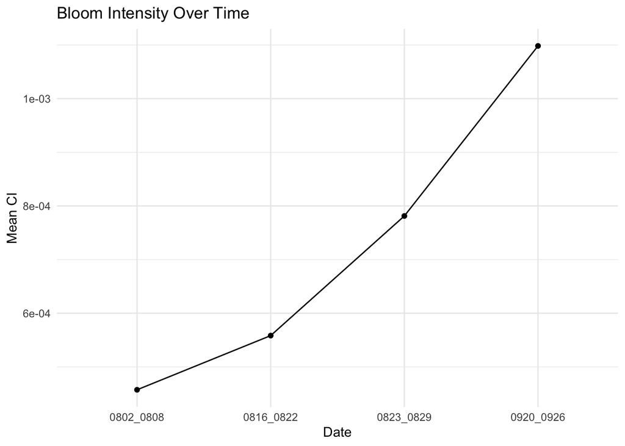

```r
# your code here
ggplot(df_time, aes(x = date, y = mean_ci, group = 1)) +
  geom_line() +
  geom_point() +
  labs(x = "Date", y = "Mean CI", title = "Bloom Intensity Over Time") +
  theme_minimal()
```

```r
best_file <- raster_files[grepl("0920_0926", raster_files)]

best_raster <- rast(best_file) %>%
  clean_cicyano() %>%
  dn_to_ci()
```

### 3.4 Binary bloom comparison

Choose any **two dates** from your dataset. For each, create a binary raster where cells with valid CI values are coded as `1` and all other cells (NA) as `0`. You will need to think about how to do this using `terra::classify()` or logical raster operations.

Use these binary rasters to create two new rasters:

- **Persistent bloom:** cells where blooms were present on *both* dates
- **New bloom:** cells where blooms were present on the *later* date but NOT the earlier date

Map both results.

*This requires careful logical thinking before writing code. Plan your approach in pseudocode first.*

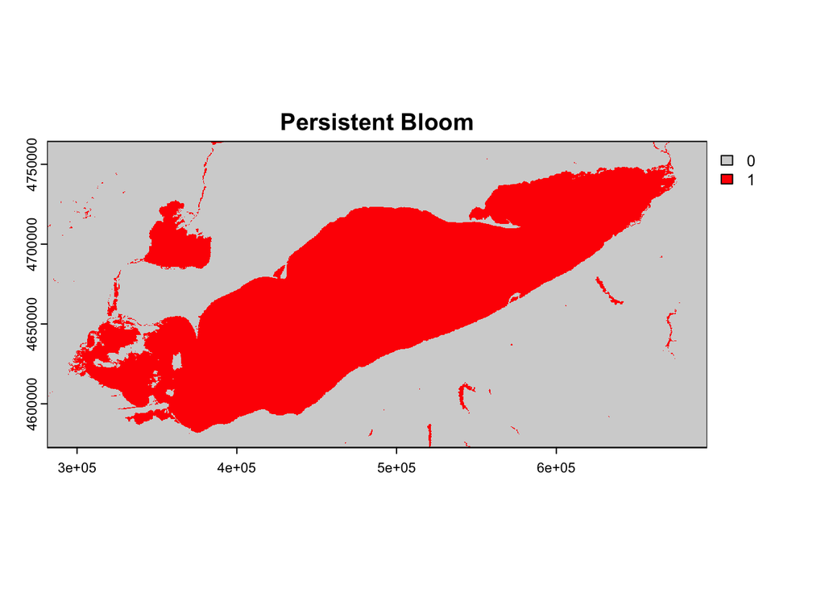

```r
# choose two dates (first = earlier, second = later)
r_early <- r_stack[[2]]
r_late  <- r_stack[[4]]

r_early_na0 <- terra::ifel(is.na(r_early), 0, r_early)
r_late_na0  <- terra::ifel(is.na(r_late), 0, r_late)

rcl <- matrix(c(
  0, 0, 0,
  0.00001, Inf, 1
), ncol = 3, byrow = TRUE)

b_early <- terra::classify(r_early_na0, rcl)
b_late  <- terra::classify(r_late_na0, rcl)

persistent_bloom <- b_early * b_late

new_bloom <- terra::ifel(b_late == 1 & b_early == 0, 1, 0)

plot(persistent_bloom,
     col = c("lightgrey", "red"),
     main = "Persistent Bloom")
```

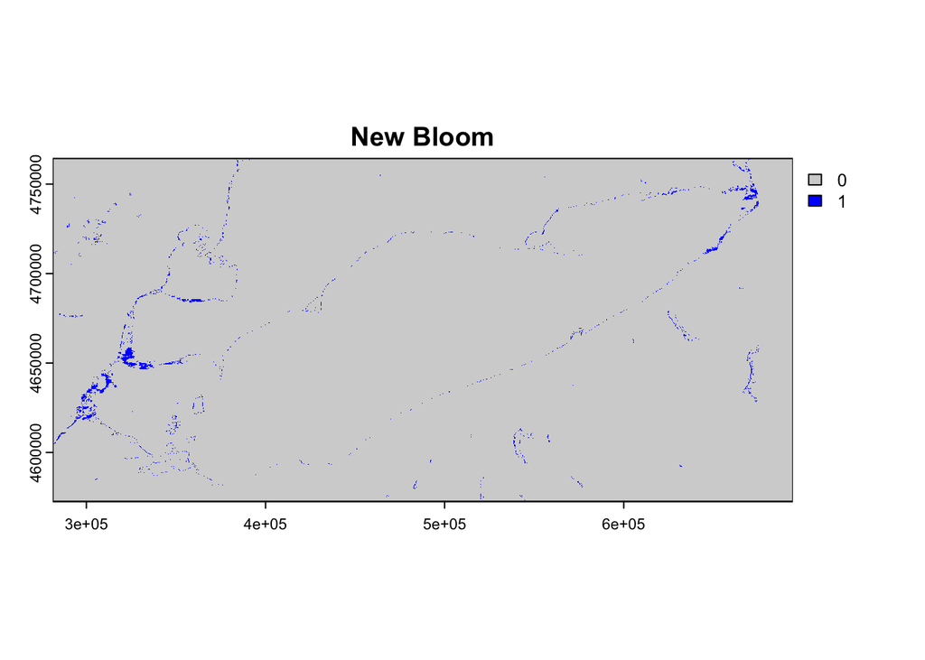

```r
plot(new_bloom,
     col = c("lightgrey", "blue"),
     main = "New Bloom")
```

### Questions for Task 3:

**Q3.1** What are the limitations of using **mean CI value** as a measure of bloom severity across the whole lake? What would be a more robust alternative metric?

it can cover up spaital variation through the lake, so maybe max CI or percent above or below CI

**Q3.2** Stacking rasters with `c()` in terra creates a multi-layer SpatRaster. What requirement must all rasters meet in order to be stacked this way? (Think: extent, resolution, CRS.)

they all need the same extent, res, and CRS

## Task 4: Zonal analysis with areas of interest

### 4.1 — Load all boundary files

Use `list.files()` to get all `.shp` files from the `bounds/` directory. Load each with `sf::read_sf()`, then combine them into a single sf object using `dplyr::bind_rows()`. Make sure each polygon has an identifier — if not, add a column with the filename or AOI name.

```r
# your code here
shp_files <- list.files("./erie_raster_ex/bounds/",
                        pattern = "\\.shp$", full.names = TRUE)

aois <- shp_files %>%
  purrr::map(~ {
    x <- sf::read_sf(.x)
    x <- sf::st_make_valid(x)
    x <- dplyr::mutate(x, aoi_name = basename(.x))
    return(x)
  }) %>%
  dplyr::bind_rows()

# convert to terra
aois_vect <- terra::vect(aois)

# check
aois
```

|  | Shape_Leng | Shape_Area | geometry | aoi_name |
| --- | --- | --- | --- | --- |
| 1 | 137537.51 | 941094393 |  | bb_erie_islands.shp |
| 2 | 324012.97 | 6602320921 |  | bb_erie_large.shp |
| 3 | 52626.95 | 177517753 |  | bb_erie_maumee.shp |
| 4 | 96611.57 | 538139738 |  | bb_erie_sandusky_plus.shp |
| 5 | 77388.50 | 258596657 |  | bb_erie_sandusky.shp |
| 6 | 102533.76 | 546752337 |  | bb_erie_west_sister.shp |

```r
aois_vect
```

```
##  class       : SpatVector
##  geometry    : polygons
##  dimensions  : 6, 3  (geometries, attributes)
##  extent      : 283549.5, 375219.9, 4586777, 4663444  (xmin, xmax, ymin, ymax)
##  coord. ref. : WGS 84 / UTM zone 17N (EPSG:32617)
##  names       : Shape_Leng Shape_Area            aoi_name
##  type        :      <num>      <num>               <chr>
##  values      :  1.375e+05  9.411e+08 bb_erie_islands.shp
##                  3.24e+05  6.602e+09   bb_erie_large.shp
##                 5.263e+04  1.775e+08  bb_erie_maumee.shp
```

### 4.2 Extract by area

Using the date you identified in Task 3.3 as having the highest mean bloom intensity, extract CI values for each area of interest using `terra::extract()`. Calculate the **mean** and **maximum** CI per AOI.

*Tip: `terra::extract()` returns a data frame. The `ID` column links rows to the AOI that was used for extraction. You can use `group_by()` and `summarize()` to aggregate.*

```r
# your code here
vals <- terra::extract(best_raster, aois_vect)

vals$aoi_name <- aois$aoi_name[vals$ID]

summary_stats <- vals %>%
  dplyr::group_by(aoi_name) %>%
  dplyr::summarize(
    mean_ci = mean(.[[2]], na.rm = TRUE),
    max_ci  = max(.[[2]], na.rm = TRUE))
```

### 4.3 Summary table

Present your results as a clean summary table. Which AOI had the highest mean CI value on that date? Which had the highest maximum?

```r
# your code here

summary_stats
```

| aoi_name | mean_ci | max_ci |
| --- | --- | --- |
| bb_erie_islands.shp | 0.008718506 | 0.0613762 |
| bb_erie_large.shp | 0.008718506 | 0.0613762 |
| bb_erie_maumee.shp | 0.008718506 | 0.0613762 |
| bb_erie_sandusky.shp | 0.008718506 | 0.0613762 |
| bb_erie_sandusky_plus.shp | 0.008718506 | 0.0613762 |
| bb_erie_west_sister.shp | 0.008718506 | 0.0613762 |

### 4.4 Map with AOI overlays

Create a `tmap` map showing the CI raster for your chosen date with the AOI boundaries overlaid. Use `tm_borders()` for the boundaries and label them if possible.

```r
tmap_mode("plot")
aois_vect <- terra::vect(aois)
terra::crs(aois_vect)
```

```
## [1] "PROJCRS[\"WGS 84 / UTM zone 17N\",\n    BASEGEOGCRS[\"WGS 84\",\n        DATUM[\"World Geodetic System 1984\",\n            ELLIPSOID[\"WGS 84\",6378137,298.257223563,\n                LENGTHUNIT[\"metre\",1]]],\n        PRIMEM[\"Greenwich\",0,\n            ANGLEUNIT[\"degree\",0.01745329251…
```

```r
terra::crs(best_raster)
```

```
## [1] "PROJCRS[\"WGS 84 / UTM zone 17N\",\n    BASEGEOGCRS[\"WGS 84\",\n        DATUM[\"World Geodetic System 1984\",\n            ELLIPSOID[\"WGS 84\",6378137,298.257223563,\n                LENGTHUNIT[\"metre\",1]]],\n        PRIMEM[\"Greenwich\",0,\n            ANGLEUNIT[\"degree\",0.01745329251…
```

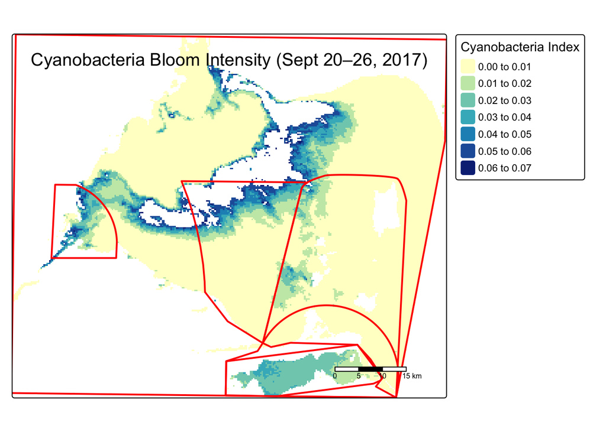

```r
aois_vect <- terra::project(aois_vect, best_raster)
raster_crop <- terra::crop(best_raster, aois_vect)
raster_mask <- terra::mask(raster_crop, aois_vect)

tm_shape(raster_mask) +
  tm_raster(
    palette = "YlGnBu",
    title = "Cyanobacteria Index"
  ) +
  tm_shape(aois_vect) +
  tm_borders(col = "red", lwd = 2) +
  tm_layout(
    title = "Cyanobacteria Bloom Intensity (Sept 20–26, 2017)",
    legend.outside = TRUE
  ) +
  tm_scalebar()
```

### Questions for Task 4:

**Q4.1** You may have gotten `NA` values in your `terra::extract()` results for some AOIs. What could cause this? Name at least two reasons.

all cells inside the AOI was NA (unable to get a clear picture ex.clouds) AOI was not within the raster vounding box

**Q4.2** Looking at the spatial distribution of your AOIs on the map, which areas do you expect to be most prone to severe blooms, and why? (Consider geography, hydrology, land use in the Lake Erie watershed.)

near river inputs there more runoffs, if theres more farms located in one area normally mean more nutrients enter.

## Questions

1. Throughout this lab you have been working with **raster** data. In what ways was the analysis workflow different from working with vector data (like you did in Labs 1–3)? What concepts translated directly, and what was fundamentally different?

i preferred working with vector data i feel like it was easier make it do what i wanted but i see how rasters our helpful since you use gridded cells and so it makes it easier to decrease the resoultion if you have a really large data set and not enough power to process it, and easier to do basic math between multiple rasters, but i like how vectors was more feature based

2. Cyanobacteria blooms are affected by temperature, nutrient runoff, and lake circulation. Based on the temporal patterns you observed in Task 3, does the timing of peak bloom match what you would expect ecologically? Explain your reasoning (I know you’re not an expert on blooms - just demonstrate thinking). bloom typically occur in late summer so august to September when the water is warm and nureitnt from farming activity is getting washed into the water so makes sense ecologically
3. We used `terra::extract()` in Task 4 to perform a zonal summary. How does this relate conceptually to the **zonal operations** category of map algebra discussed in class?

because it defines raster values within zones